# GitHub

Dado mais recente: **19 set 2026**Página construída em 19 set 2026, 11:30 UTC. Todo gráfico abaixo é datado pelo seu dado, nunca por este build.

Estado de cada repositório curado, atividade de issues e pull requests, tráfego desde o início da coleta e commits como série secundária.

ⓘ Apenas agregados por repositório. Nenhum título de issue, autor ou endereço de e-mail é coletado ou publicado.

## Estado dos repositórios

Snapshot de 19 set 2026

| Repositório | Issues abertas | PRs abertos | Issue aberta mais antiga | Estrelas | Forks | Observadores | Último push | Arquivado |
| --- | --- | --- | --- | --- | --- | --- | --- | --- |
| evandeilton/betaregscale | 0 | 0 | nenhum | 1 | 0 | 1 | 15 set 2026, 23:22 UTC | não |
| evandeilton/gkwdist | 0 | 0 | nenhum | 1 | 0 | 0 | 16 set 2026, 21:43 UTC | não |
| evandeilton/gkwreg | 0 | 0 | nenhum | 2 | 0 | 1 | 23 ago 2026, 18:37 UTC | não |
| evandeilton/OptimalBinningWoE | 0 | 0 | nenhum | 4 | 0 | 2 | 4 set 2026, 12:38 UTC | não |
| evandeilton/rnp | 1 | 0 | 2.746 dias | 2 | 0 | 1 | 22 jun 2026, 17:01 UTC | não |

## Idade da issue aberta mais antiga

Idade, não contagem: uma issue aberta antiga é um sinal, um acúmulo de issues recentes normalmente não é.

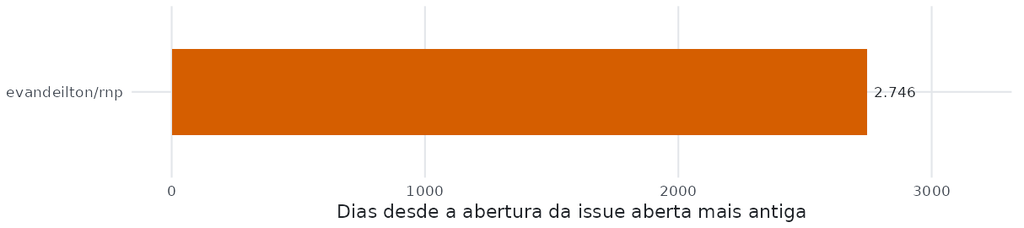

Dados do gráfico até 19 set 2026.

## Atividade de issues e pull requests

Contagens diárias por repositório. Pull requests mesclados e fechados são disjuntos: um pull request mesclado é contado apenas como mesclado.

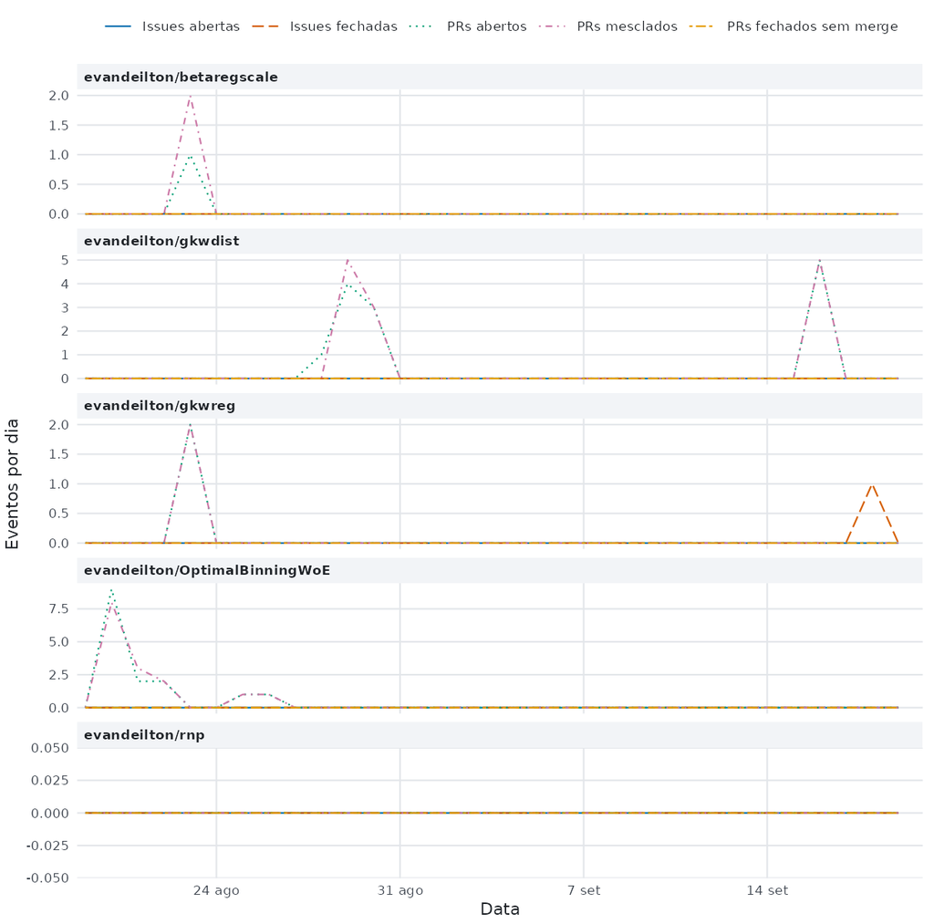

Dados do gráfico até 19 set 2026.

## Tráfego

Visualizações e clones por repositório. A API de tráfego do GitHub retém quatorze dias e nada mais, então esta série é a única cópia de longo prazo do dado e começa no dia em que a coleta foi iniciada.

Nenhum tráfego foi coletado ainda.

## Releases

Tabela permanente, da mais recente para a mais antiga.

| Repositório | Tag | Nome | Publicada | Pré-release |
| --- | --- | --- | --- | --- |
| evandeilton/gkwdist | v1.1.6 | v1.1.6 — Base R contract, 25 correctness fixes, and a full documentation audit | 30 ago 2026, 02:59 UTC | não |
| evandeilton/gkwreg | v2.1.18 | gkwreg 2.1.18 | 23 ago 2026, 18:23 UTC | não |
| evandeilton/betaregscale | v2.7.4 | betaregscale 2.7.4 — vignette build time cut 5.3x for CRAN | 23 ago 2026, 17:32 UTC | não |
| evandeilton/betaregscale | v2.7.3 | betaregscale 2.7.3 — interval likelihood conditioning, CRAN prep | 23 ago 2026, 02:13 UTC | não |
| evandeilton/gkwreg | v2.1.17 | gkwreg 2.1.17 | 23 ago 2026, 00:37 UTC | não |
| evandeilton/OptimalBinningWoE | v1.13.3 | v1.13.3 — Silent-answer audit: data loss, memory safety, ignored constraints, and a 1000× speedup | 22 ago 2026, 23:20 UTC | não |
| evandeilton/OptimalBinningWoE | v1.13.2 | v1.13.2 — Audit fixes: silent scoring defects, behavior changes and CI hardening | 20 ago 2026, 23:13 UTC | não |
| evandeilton/OptimalBinningWoE | v1.13.0 | v1.13.0 — `obwoe_scorecard()` the pipeline as one reviewable artefact | 20 ago 2026, 12:26 UTC | não |
| evandeilton/OptimalBinningWoE | v1.11.0 | v1.11.0 — Runtime audit: crash, hang, data-loss and reproducibility fixes | 12 ago 2026, 21:15 UTC | não |
| evandeilton/gkwdist | v1.1.5 | v1.1.5 — Numerical correctness fixes and componentwise derivative validation | 11 ago 2026, 18:09 UTC | não |
| evandeilton/gkwdist | v1.1.4 | v1.1.4 — CRAN fix: skip timing-based tests on CRAN | 27 mai 2026, 19:49 UTC | não |
| evandeilton/betaregscale | v2.7.1 | betaregscale v2.7.1 — Correctness & robustness audit | 23 mai 2026, 19:08 UTC | não |
| evandeilton/gkwdist | v1.1.3 | v1.1.3 — Critical MLE Bug Fixes & Numerical Corrections | 21 mai 2026, 00:35 UTC | não |
| evandeilton/OptimalBinningWoE | v1.10.0 | v1.10.0 — C++ Engine Audit & Hardening | 17 mai 2026, 16:41 UTC | não |
| evandeilton/OptimalBinningWoE | v1.0.9 | OptimalBinningWoE 1.0.9 | 14 mar 2026, 17:10 UTC | não |
| evandeilton/betaregscale | v2.7.0 | betaregscale 2.7.0 | 28 fev 2026, 00:06 UTC | não |
| evandeilton/betaregscale | v2.6.9 | betaregscale 2.6.9 | 21 fev 2026, 22:06 UTC | não |
| evandeilton/betaregscale | v2.6.8 | betaregscale 2.6.8 | 21 fev 2026, 19:52 UTC | não |
| evandeilton/betaregscale | v2.6.7 | betaregscale v2.6.7 - CRAN Resubmission | 20 fev 2026, 13:54 UTC | não |
| evandeilton/betaregscale | v2.6.6 | betaregscale 2.6.6 | 18 fev 2026, 16:02 UTC | não |
| evandeilton/betaregscale | v2.6.5 | betaregscale 2.6.5 | 18 fev 2026, 03:28 UTC | não |
| evandeilton/betaregscale | v2.6.3 | betaregscale 2.6.3 | 17 fev 2026, 02:11 UTC | não |
| evandeilton/betaregscale | v2.6.1 | betaregscale 2.6.1 | 16 fev 2026, 02:25 UTC | não |
| evandeilton/betaregscale | v2.6.0 | betaregscale 2.6.0 | 15 fev 2026, 20:19 UTC | não |
| evandeilton/OptimalBinningWoE | v1.0.8 | OptimalBinningWoE 1.0.8 | 29 jan 2026, 15:26 UTC | não |
| evandeilton/OptimalBinningWoE | v1.0.7 | OptimalBinningWoE 1.0.7 | 28 jan 2026, 02:21 UTC | não |
| evandeilton/gkwreg | v2.1.16 | JOSS submission - Reviewed version [Zenodo] | 18 jan 2026, 18:22 UTC | não |
| evandeilton/gkwreg | v2.1.15 | JOSS submission - reviewed version | 18 jan 2026, 18:10 UTC | não |
| evandeilton/gkwreg | v2.1.14 | gkwreg 2.1.14 | 8 jan 2026, 21:01 UTC | não |
| evandeilton/gkwdist | v1.1.2 | gkwdist 1.1.2 | 8 jan 2026, 21:00 UTC | não |
| evandeilton/gkwreg | v2.1.5 | gkwreg 2.1.5 | 27 nov 2025, 00:22 UTC | não |
| evandeilton/gkwdist | v1.1.1 | gkwdist 1.1.1 | 26 nov 2025, 23:18 UTC | não |
| evandeilton/gkwreg | v2.1.4 | gkwreg 2.1.4 | 16 nov 2025, 14:42 UTC | não |
| evandeilton/gkwdist | v1.0.10 | gkwdist 1.0.10 | 16 nov 2025, 14:35 UTC | não |

## Commits, série secundária

Publicado aqui e em nenhum outro lugar, deliberadamente. O volume bruto de commits está sujeito à lei de Goodhart: mede digitação, não produção. Aparece como uma série entre outras, nunca como número de destaque, e o painel não define meta nem acompanha sequência.

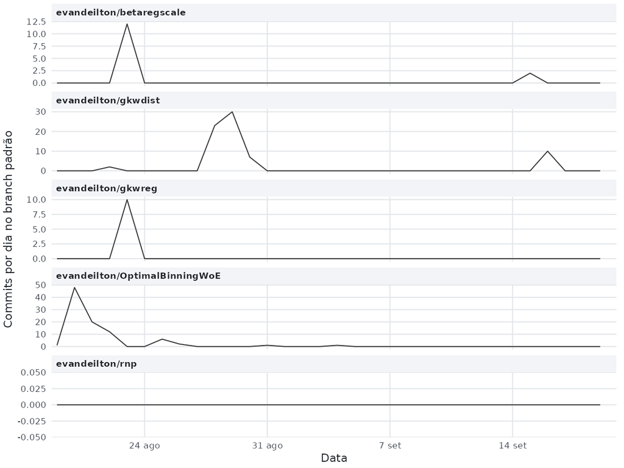

Dados do gráfico até 19 set 2026.